# Inventory Monitoring at Distribution Centers

**Note:** This notebook has a bunch of code and markdown cells with TODOs that you have to complete. These are meant to be helpful guidelines for you to finish your project while meeting the requirements in the project rubrics. Feel free to change the order of the TODO's and/or use more than one cell to complete all the tasks.

```python
import sagemaker
import boto3
import os

role = sagemaker.get_execution_role()
bucket = sagemaker.Session().default_bucket()
print(role)
print("bucket", bucket)
```

```
arn:aws:iam::523060554049:role/service-role/AmazonSageMaker-ExecutionRole-20241113T150811
bucket sagemaker-us-east-1-523060554049
```

## Data Preparation

**TODO:** Run the cell below to download the data.

The cell below creates a folder called `train_data`, downloads training data and arranges it in subfolders. Each of these subfolders contain images where the number of objects is equal to the name of the folder. For instance, all images in folder `1` has images with 1 object in them. Images are not divided into training, testing or validation sets. If you feel like the number of samples are not enough, you can always download more data (instructions for that can be found [here](https://registry.opendata.aws/amazon-bin-imagery/)). However, we are not acessing you on the accuracy of your final trained model, but how you create your machine learning engineering pipeline.

```python
import os
import json
import boto3

def download_and_arrange_data():
    s3_client = boto3.client('s3')

    with open('file_list.json', 'r') as f:
        d=json.load(f)

    for k, v in d.items():
        print(f"Downloading Images with {k} objects")
        directory=os.path.join('train_data', k)
        if not os.path.exists(directory):
            os.makedirs(directory)
        for file_path in v:
            file_name=os.path.basename(file_path).split('.')[0]+'.jpg'
            s3_client.download_file('aft-vbi-pds', os.path.join('bin-images', file_name),
                             os.path.join(directory, file_name))

download_and_arrange_data()
```

```
Downloading Images with 1 objects
Downloading Images with 2 objects
Downloading Images with 3 objects
Downloading Images with 4 objects
Downloading Images with 5 objects
```

## Dataset

```python
f = open('file_list.json', 'r')
d=json.load(f)
class_length = {}
for k, v in d.items():
    class_length[k] = len(v)
print(class_length)
```

```
{'1': 1228, '2': 2299, '3': 2666, '4': 2373, '5': 1875}
```

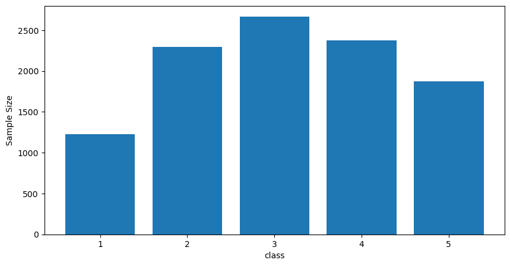

```python
import matplotlib.pyplot as plt
plt.figure(figsize = (10, 5))
plt.bar(list(class_length.keys()), list(class_length.values()))
plt.xlabel("class")
plt.ylabel("Sample Size")
plt.show()
```

```python
#for each class move 20 percent to test folder
import os
import shutil
import random
test_folder = "test_data"
valid_folder= "valid_data"
train_folder = "train_data"
os.mkdir(test_folder)
os.mkdir(valid_folder)
for _class in class_length:
    print("data moving for class "+str(_class))
    total_size = class_length[_class]
    test_size = total_size*20//100
    valid_size = (total_size-test_size)*20//100
    src_folder = train_folder+"/"+_class
    test_dist_folder = test_folder+"/"+_class
    valid_dist_folder = valid_folder+"/"+_class
    os.mkdir(test_dist_folder)
    os.mkdir(valid_dist_folder)
    all_files = [f for f in os.listdir(src_folder)]
    files_to_test = set(random.sample(all_files, test_size))
    print("took random samples to test for size " + str(test_size))
    remaining_files = set(all_files).difference(files_to_test)
    files_to_valid = random.sample(list(remaining_files), valid_size)
    print("took random samples to valid for size " + str(valid_size))
    print("Moving files to test_folder...")
    for file_name in files_to_test:
        src_file = os.path.join(src_folder, file_name)
        dest_file = os.path.join(test_dist_folder, file_name)
        shutil.move(src_file, dest_file)
    print("Moving files to valid_folder...")
    for file_name in files_to_valid:
        src_file = os.path.join(src_folder, file_name)
        dest_file = os.path.join(valid_dist_folder, file_name)
        shutil.move(src_file, dest_file)
```

```
data moving for class 1
took random samples to test for size 245
took random samples to valid for size 196
Moving files to test_folder...
Moving files to valid_folder...
data moving for class 2
took random samples to test for size 459
took random samples to valid for size 368
Moving files to test_folder...
Moving files to valid_folder...
data moving for class 3
took random samples to test for size 533
took random samples to valid for size 426
Moving files to test_folder...
Moving files to valid_folder...
data moving for class 4
took random samples to test for size 474
took random samples to valid for size 379
Moving files to test_folder...
Moving files to valid_folder...
data moving for class 5
took random samples to test for size 375
took random samples to valid for size 300
Moving files to test_folder...
Moving files to valid_folder...
```

```python
#move folders

def move_folders(src_folders, dest_folder):
    if not os.path.exists(dest_folder):
        os.makedirs(dest_folder)
        print(f"Created destination folder: {dest_folder}")

    for folder in src_folders:
        src_folder = os.path.join(os.getcwd(), folder)
        dest_folder_path = os.path.join(dest_folder, folder)
        if os.path.exists(src_folder) and os.path.isdir(src_folder):
            shutil.move(src_folder, dest_folder_path)
            print(f"Moved: {folder} to {dest_folder}")
        else:
            print(f"Source folder does not exist: {folder}")

# Example usage
src_folders = ['test_data', 'train_data', 'valid_data']  # List of folders to move
dest_folder = 'binImages'  # Destination folder

move_folders(src_folders, dest_folder)
```

```
Created destination folder: binImages
Moved: test_data to binImages
Moved: train_data to binImages
Moved: valid_data to binImages
```

[figure not shown]

```python
#sample of 1 object in bin
image = plt.imread("binImages/train_data/1/00048.jpg")
plt.imshow(image)
plt.show()
```

[figure not shown]

```python
#sample of 2 objects in bin
image = plt.imread("binImages/train_data/2/00025.jpg")
plt.imshow(image)
plt.show()
```

[figure not shown]

```python
#sample of 3 objects in bin
image = plt.imread("binImages/train_data/3/00031.jpg")
plt.imshow(image)
plt.show()
```

[figure not shown]

```python
#sample of 4 objects in bin
image = plt.imread("binImages/train_data/4/00010.jpg")
plt.imshow(image)
plt.show()
```

[figure not shown]

```python
#sample of 5 objects in bin
image = plt.imread("binImages/train_data/5/00018.jpg")
plt.imshow(image)
plt.show()
```

```python
s3_path = sagemaker.Session().upload_data(
    path="binImages",
    bucket=bucket,
    key_prefix="BinObjectCounter/Bins"
)

print(f"{s3_path=}")
```

```
s3_path='s3://sagemaker-us-east-1-523060554049/BinObjectCounter/Bins'
```

```python
s3_path='s3://sagemaker-us-east-1-523060554049/BinObjectCounter/Bins'
```

## Model Training

**Note:** You will need to use the `train.py` script to train your model.

```python
from sagemaker.tuner import IntegerParameter, CategoricalParameter, ContinuousParameter, HyperparameterTuner
from sagemaker.pytorch import PyTorch
hyperparameter_ranges = {
    "lr": ContinuousParameter(0.001, 0.1),
    "batch_size": CategoricalParameter([16, 32, 64, 128]),
    "epochs": CategoricalParameter([5, 10])
}
objective_metric_name = "Test Loss"
objective_type = "Minimize"
metric_definitions = [{"Name": "Test Loss", "Regex": "Testing Loss: ([0-9\\.]+)"}]
```

```python
estimator = PyTorch(
    entry_point="train.py",
    role=role,
    py_version="py36",
    framework_version="1.8",
    instance_count=1,
    instance_type="ml.g4dn.xlarge"
)

tuner = HyperparameterTuner(
    estimator = estimator,
    early_stopping_type = "Auto",
    metric_definitions = metric_definitions,
    objective_metric_name = objective_metric_name,
    objective_type = objective_type,
    max_jobs = 4,
    max_parallel_jobs = 2,
    hyperparameter_ranges = hyperparameter_ranges
)
```

```python
os.environ['SM_CHANNEL_TRAINING']=s3_path
os.environ['SM_MODEL_DIR']=f's3://{bucket}/BinObjectCounter/Bins/model'
os.environ['SM_OUTPUT_DATA_DIR']=f's3://{bucket}/BinObjectCounter/Bins/output'
tuner.fit({"training": s3_path},wait=True)
```

```
No finished training job found associated with this estimator. Please make sure this estimator is only used for building workflow config
No finished training job found associated with this estimator. Please make sure this estimator is only used for building workflow config
```

[output not shown]

```python
best_estimator = tuner.best_estimator()

#Get the hyperparameters of the best trained model
best_estimator_hp = best_estimator.hyperparameters()
best_estimator_hp
```

```
2024-11-14 20:21:17 Starting - Found matching resource for reuse
2024-11-14 20:21:17 Downloading - Downloading the training image
2024-11-14 20:21:17 Training - Training image download completed. Training in progress.
2024-11-14 20:21:17 Uploading - Uploading generated training model
2024-11-14 20:21:17 Completed - Resource released due to keep alive period expiry
```

```
{'_tuning_objective_metric': '"Test Loss"',
 'batch_size': '"16"',
 'epochs': '"5"',
 'lr': '0.012927382730406068',
 'sagemaker_container_log_level': '20',
 'sagemaker_estimator_class_name': '"PyTorch"',
 'sagemaker_estimator_module': '"sagemaker.pytorch.estimator"',
 'sagemaker_job_name': '"pytorch-training-2024-11-14-19-58-51-128"',
 'sagemaker_program': '"train.py"',
 'sagemaker_region': '"us-east-1"',
 'sagemaker_submit_directory': '"s3://sagemaker-us-east-1-523060554049/pytorch-training-2024-11-14-19-58-51-128/source/sourcedir.tar.gz"'}
```

```python
from sagemaker.analytics import HyperparameterTuningJobAnalytics

exp = HyperparameterTuningJobAnalytics(
  hyperparameter_tuning_job_name="pytorch-training-241114-1958")

jobs = exp.dataframe()

jobs.sort_values('FinalObjectiveValue', ascending=0)
```

|  | batch_size | epochs | lr | TrainingJobName | TrainingJobStatus | FinalObjectiveValue | TrainingStartTime | TrainingEndTime | TrainingElapsedTimeSeconds |
| --- | --- | --- | --- | --- | --- | --- | --- | --- | --- |
| 2 | "128" | "5" | 0.058185 | pytorch-training-241114-1958-002-dc2fa01c | Completed | 1.596853 | 2024-11-14 19:59:44+00:00 | 2024-11-14 20:12:02+00:00 | 738.0 |
| 3 | "64" | "10" | 0.088724 | pytorch-training-241114-1958-001-390d8933 | Completed | 1.583377 | 2024-11-14 19:59:43+00:00 | 2024-11-14 20:18:18+00:00 | 1115.0 |
| 0 | "128" | "5" | 0.051661 | pytorch-training-241114-1958-004-c1653c5a | Completed | 1.537071 | 2024-11-14 20:18:30+00:00 | 2024-11-14 20:25:50+00:00 | 440.0 |
| 1 | "16" | "5" | 0.012927 | pytorch-training-241114-1958-003-d5a7fe3c | Completed | 1.528551 | 2024-11-14 20:13:54+00:00 | 2024-11-14 20:21:15+00:00 | 441.0 |

```python
tuner.describe()
```

```
{'HyperParameterTuningJobName': 'pytorch-training-241114-1958',
 'HyperParameterTuningJobArn': 'arn:aws:sagemaker:us-east-1:523060554049:hyper-parameter-tuning-job/pytorch-training-241114-1958',
 'HyperParameterTuningJobConfig': {'Strategy': 'Bayesian',
  'HyperParameterTuningJobObjective': {'Type': 'Minimize',
   'MetricName': 'Test Loss'},
  'ResourceLimits': {'MaxNumberOfTrainingJobs': 4,
   'MaxParallelTrainingJobs': 2},
  'ParameterRanges': {'IntegerParameterRanges': [],
   'ContinuousParameterRanges': [{'Name': 'lr',
     'MinValue': '0.001',
     'MaxValue': '0.1',
     'ScalingType': 'Auto'}],
   'CategoricalParameterRanges': [{'Name': 'batch_size',
     'Values': ['"16"', '"32"', '"64"', '"128"']},
    {'Name': 'epochs', 'Values': ['"5"', '"10"']}]},
  'TrainingJobEarlyStoppingType': 'Auto'},
 'TrainingJobDefinition': {'StaticHyperParameters': {'_tuning_objective_metric': 'Test Loss',
   'sagemaker_container_log_level': '20',
   'sagemaker_estimator_class_name': '"PyTorch"',
   'sagemaker_estimator_module': '"sagemaker.pytorch.estimator"',
   'sagemaker_job_name': '"pytorch-training-2024-11-14-19-58-51-128"',
   'sagemaker_program': '"train.py"',
   'sagemaker_region': '"us-east-1"',
   'sagemaker_submit_directory': '"s3://sagemaker-us-east-1-523060554049/pytorch-training-2024-11-14-19-58-51-128/source/sourcedir.tar.gz"'},
  'AlgorithmSpecification': {'TrainingImage': '763104351884.dkr.ecr.us-east-1.amazonaws.com/pytorch-training:1.8-gpu-py36',
   'TrainingInputMode': 'File',
   'MetricDefinitions': [{'Name': 'Test Loss',
     'Regex': 'Testing Loss: ([0-9\\.]+)'},
    {'Name': 'ObjectiveMetric', 'Regex': 'Testing Loss: ([0-9\\.]+)'}]},
  'RoleArn': 'arn:aws:iam::523060554049:role/service-role/AmazonSageMaker-ExecutionRole-20241113T150811',
  'InputDataConfig': [{'ChannelName': 'training',
    'DataSource': {'S3DataSource': {'S3DataType': 'S3Prefix',
      'S3Uri': 's3://sagemaker-us-east-1-523060554049/BinObjectCounter/Bins',
      'S3DataDistributionType': 'FullyReplicated'}}}],
  'OutputDataConfig': {'S3OutputPath': 's3://sagemaker-us-east-1-523060554049/'},
  'ResourceConfig': {'InstanceType': 'ml.g4dn.xlarge',
   'InstanceCount': 1,
   'VolumeSizeInGB': 30},
  'StoppingCondition': {'MaxRuntimeInSeconds': 86400},
  'EnableNetworkIsolation': False,
```

[output cut: 18 more lines]

```
  'TunedHyperParameters': {'batch_size': '"16"',
   'epochs': '"5"',
   'lr': '0.012927382730406068'},
  'FinalHyperParameterTuningJobObjectiveMetric': {'MetricName': 'Test Loss',
   'Value': 1.5285511016845703},
  'ObjectiveStatus': 'Succeeded'},
 'TuningJobCompletionDetails': {'NumberOfTrainingJobsObjectiveNotImproving': 1},
 'ConsumedResources': {'RuntimeInSeconds': 1621},
 'ResponseMetadata': {'RequestId': 'c9d5295a-4142-4523-9208-08fa11295511',
  'HTTPStatusCode': 200,
  'HTTPHeaders': {'x-amzn-requestid': 'c9d5295a-4142-4523-9208-08fa11295511',
   'content-type': 'application/x-amz-json-1.1',
   'content-length': '3360',
   'date': 'Thu, 14 Nov 2024 20:39:55 GMT'},
  'RetryAttempts': 0}}
```

```python
TrainingJobName= 'pytorch-training-241114-1958-003-d5a7fe3c'
best_estimator_check = sagemaker.estimator.Estimator.attach(TrainingJobName)
best_estimator_check_hp = best_estimator_check.hyperparameters()
best_estimator_check_hp
```

```
2024-11-14 20:21:17 Starting - Found matching resource for reuse
2024-11-14 20:21:17 Downloading - Downloading the training image
2024-11-14 20:21:17 Training - Training image download completed. Training in progress.
2024-11-14 20:21:17 Uploading - Uploading generated training model
2024-11-14 20:21:17 Completed - Resource released due to keep alive period expiry
```

```
{'_tuning_objective_metric': 'Test Loss',
 'batch_size': '"16"',
 'epochs': '"5"',
 'lr': '0.012927382730406068',
 'sagemaker_container_log_level': '20',
 'sagemaker_estimator_class_name': '"PyTorch"',
 'sagemaker_estimator_module': '"sagemaker.pytorch.estimator"',
 'sagemaker_job_name': '"pytorch-training-2024-11-14-19-58-51-128"',
 'sagemaker_program': '"train.py"',
 'sagemaker_region': '"us-east-1"',
 'sagemaker_submit_directory': '"s3://sagemaker-us-east-1-523060554049/pytorch-training-2024-11-14-19-58-51-128/source/sourcedir.tar.gz"'}
```

## Standout Suggestions

You do not need to perform the tasks below to finish your project. However, you can attempt these tasks to turn your project into a more advanced portfolio piece.

### Hyperparameter Tuning

- tune as many hyperparameters as you can to get the best performance from your model
- explain why you chose to tune those particular hyperparameters and the ranges.

```python
hyperparameters = {"batch_size": int(best_estimator_check_hp['batch_size'].replace('"', '')),
                   "lr": best_estimator_check_hp['lr'], "epochs" : int(best_estimator_check_hp['epochs'].replace('"', ''))}
hyperparameters
```

```
{'batch_size': 16, 'lr': '0.012927382730406068', 'epochs': 5}
```

```python
from sagemaker.debugger import Rule, ProfilerRule, rule_configs, CollectionConfig
from sagemaker.debugger import DebuggerHookConfig, ProfilerConfig, FrameworkProfile

rules = [
    Rule.sagemaker(rule_configs.vanishing_gradient()),
    Rule.sagemaker(rule_configs.overfit()),
    Rule.sagemaker(rule_configs.overtraining()),
    Rule.sagemaker(rule_configs.poor_weight_initialization()),
    ProfilerRule.sagemaker(rule_configs.ProfilerReport()),
]
collection_configs=[CollectionConfig(name="CrossEntropyLoss_output_0",parameters={
    "include_regex": "CrossEntropyLoss_output_0", "train.save_interval": "10","eval.save_interval": "1"})]

profiler_config = ProfilerConfig(
    system_monitor_interval_millis=500, framework_profile_params=FrameworkProfile(num_steps=1)
)
debugger_hook_config=DebuggerHookConfig(
    hook_parameters={
        "train.save_interval": "100",
        "eval.save_interval": "10"
    },
    collection_configs=collection_configs
)
```

```
Framework profiling will be deprecated from tensorflow 2.12 and pytorch 2.0 in sagemaker>=2.
See: https://sagemaker.readthedocs.io/en/stable/v2.html for details.
```

```python
estimator =PyTorch(
    entry_point="train.py",
    role=role,
    py_version="py36",
    framework_version="1.8",
    instance_count=1,
    instance_type="ml.g4dn.xlarge",
    #debugging and profiling rules and hooks
    hyperparameters=hyperparameters,
    rules=rules,
    debugger_hook_config=debugger_hook_config,
    profiler_config=profiler_config,
)
estimator.fit({"training": s3_path},wait=True)
```

```
INFO:sagemaker.image_uris:image_uri is not presented, retrieving image_uri based on instance_type, framework etc.
INFO:sagemaker:Creating training-job with name: pytorch-training-2024-11-14-20-52-15-676
```

```
2024-11-14 20:52:16 Starting - Starting the training job...
2024-11-14 20:52:43 Starting - Preparing the instances for trainingVanishingGradient: InProgress
Overfit: InProgress
Overtraining: InProgress
PoorWeightInitialization: InProgress
ProfilerReport: InProgress
...
2024-11-14 20:53:15 Downloading - Downloading input data......
2024-11-14 20:54:08 Downloading - Downloading the training image................
```

```python
estimator
```

```
<sagemaker.pytorch.estimator.PyTorch at 0x7f3b966ee150>
```

```python
job_name = estimator.latest_training_job.name
client = estimator.sagemaker_session.sagemaker_client
description = client.describe_training_job(TrainingJobName=estimator.latest_training_job.name)
print(job_name)
print(description)
```

```
pytorch-training-2024-11-14-20-52-15-676
{'TrainingJobName': 'pytorch-training-2024-11-14-20-52-15-676', 'TrainingJobArn': 'arn:aws:sagemaker:us-east-1:523060554049:training-job/pytorch-training-2024-11-14-20-52-15-676', 'ModelArtifacts': {'S3ModelArtifacts': 's3://sagemaker-us-east-1-523060554049/pytorch-training-2024-11-14-20-52-15-676/o…
```

```python
!pip install smdebug
```

[output not shown]

```python
pip install protobuf==3.20.
```

[output not shown]

```python
pip install bokeh
```

[output not shown]

```python
from smdebug.profiler.analysis.notebook_utils.training_job import TrainingJob
from smdebug.profiler.analysis.notebook_utils.timeline_charts import TimelineCharts
session = boto3.session.Session()
region = session.region_name

training_job = TrainingJob(job_name, region)
training_job.wait_for_sys_profiling_data_to_be_available()
```

```
ProfilerConfig:{'S3OutputPath': 's3://sagemaker-us-east-1-523060554049/', 'ProfilingIntervalInMilliseconds': 500, 'ProfilingParameters': {'DataloaderProfilingConfig': '{"StartStep": 0, "NumSteps": 1, "MetricsRegex": ".*", }', 'DetailedProfilingConfig': '{"StartStep": 0, "NumSteps": 1, }', 'FileOpenF…
s3 path:s3://sagemaker-us-east-1-523060554049/pytorch-training-2024-11-14-20-52-15-676/profiler-output


Profiler data from system is available
```

```python
system_metrics_reader = training_job.get_systems_metrics_reader()
system_metrics_reader.refresh_event_file_list()
```

```python
rule_output_path = estimator.output_path + estimator.latest_training_job.job_name + "/rule-output"
print(f"You will find the profiler report in {rule_output_path}")
```

```
You will find the profiler report in s3://sagemaker-us-east-1-523060554049/pytorch-training-2024-11-14-20-52-15-676/rule-output
```

```python
! aws s3 ls {rule_output_path} --recursive
! aws s3 cp {rule_output_path} ./ --recursive
```

[output not shown]

```python
profiler_report_name = [
    rule["RuleConfigurationName"]
    for rule in estimator.latest_training_job.rule_job_summary()
    if "Profiler" in rule["RuleConfigurationName"]
][0]
import IPython

IPython.display.HTML(filename=profiler_report_name + "/profiler-output/profiler-report.html")
```

SageMaker Debugger Profiling Report

SageMaker Debugger auto generated this report. You can generate similar reports on all supported training jobs. The report provides summary of training job, system resource usage statistics, framework metrics, rules summary, and detailed analysis from each rule. The graphs and tables are interactive.

**Legal disclaimer:** This report and any recommendations are provided for informational purposes only and are not definitive. You are responsible for making your own independent assessment of the information.

```
# Parameters
processing_job_arn = "arn:aws:sagemaker:us-east-1:523060554049:processing-job/pytorch-training-2024-11-1-ProfilerReport-a8249390"
```

Training job summary

[interactive chart not shown]

System usage statistics

[interactive chart not shown]

Framework metrics summary

[interactive chart not shown]

Overview: CPU operators

[interactive chart not shown]

Overview: GPU operators

[interactive chart not shown]

Rules summary

The following table shows a profiling summary of the Debugger built-in rules. The table is sorted by the rules that triggered the most frequently. During your training job, the BatchSize rule was the most frequently triggered. It processed 1405 datapoints and was triggered 4 times.

|  | Description | Recommendation | Number of times rule triggered | Number of datapoints | Rule parameters |
| --- | --- | --- | --- | --- | --- |
| BatchSize | Checks if GPUs are underutilized because the batch size is too small. To detect this problem, the rule analyzes the average GPU memory footprint, the CPU and the GPU utilization. | The batch size is too small, and GPUs are underutilized. Consider running on a smaller instance type or increasing the batch size. | 4 | 1405 | cpu_threshold_p95:70 gpu_threshold_p95:70 gpu_memory_threshold_p95:70 patience:1000 window:500 |
| LowGPUUtilization | Checks if the GPU utilization is low or fluctuating. This can happen due to bottlenecks, blocking calls for synchronizations, or a small batch size. | Check if there are bottlenecks, minimize blocking calls, change distributed training strategy, or increase the batch size. | 4 | 1406 | threshold_p95:70 threshold_p5:10 window:500 patience:1000 |
| LoadBalancing | Detects workload balancing issues across GPUs. Workload imbalance can occur in training jobs with data parallelism. The gradients are accumulated on a primary GPU, and this GPU might be overused with … | Choose a different distributed training strategy or a different distributed training framework. | 0 | 1406 | threshold:0.2 patience:1000 |
| IOBottleneck | Checks if the data I/O wait time is high and the GPU utilization is low. It might indicate IO bottlenecks where GPU is waiting for data to arrive from storage. The rule evaluates the I/O and GPU utili… | Pre-fetch data or choose different file formats, such as binary formats that improve I/O performance. | 0 | 1409 | threshold:50 io_threshold:50 gpu_threshold:10 patience:1000 |
| CPUBottleneck | Checks if the CPU utilization is high and the GPU utilization is low. It might indicate CPU bottlenecks, where the GPUs are waiting for data to arrive from the CPUs. The rule evaluates the CPU and GPU… | Consider increasing the number of data loaders or applying data pre-fetching. | 0 | 1409 | threshold:50 cpu_threshold:90 gpu_threshold:10 patience:1000 |
| MaxInitializationTime | Checks if the time spent on initialization exceeds a threshold percent of the total training time. The rule waits until the first step of training loop starts. The initialization can take longer if do… | Initialization takes too long. If using File mode, consider switching to Pipe mode in case you are using TensorFlow framework. | 0 | 2675 | threshold:20 |
| StepOutlier | Detects outliers in step duration. The step duration for forward and backward pass should be roughly the same throughout the training. If there are significant outliers, it may indicate a system stall… | Check if there are any bottlenecks (CPU, I/O) correlated to the step outliers. | 0 | 2675 | threshold:3 mode:None n_outliers:10 stddev:3 |
| GPUMemoryIncrease | Measures the average GPU memory footprint and triggers if there is a large increase. | Choose a larger instance type with more memory if footprint is close to maximum available memory. | 0 | 1406 | increase:5 patience:1000 window:10 |
| Dataloader | Checks how many data loaders are running in parallel and whether the total number is equal the number of available CPU cores. The rule triggers if number is much smaller or larger than the number of a… | Change the number of data loader processes. | 0 | 1 | min_threshold:70 max_threshold:200 |

Analyzing the training loop

Step duration analysis

[interactive chart not shown]

**Step durations on node algo-1-33:**

The following table is a summary of the statistics of step durations measured on node algo-1-33. The rule has analyzed the step duration from Step:ModeKeys.GLOBAL phase. The average step duration on node algo-1-33 was 0.03s. The rule detected 6 outliers, where step duration was larger than 3 times the standard deviation of 0.25s

|  | mean | max | p99 | p95 | p50 | min |
| --- | --- | --- | --- | --- | --- | --- |
| Step Durations in [s] | 0.03 | 12.37 | 0.03 | 0.02 | 0.02 | 0.02 |

The following histogram shows the step durations measured on the different nodes. You can turn on or turn off the visualization of histograms by selecting or unselecting the labels in the legend.

[interactive chart not shown]

GPU utilization analysis

**Usage per GPU**

[interactive chart not shown]

**GPU utilization of gpu0 on node algo-1:**

[interactive chart not shown]

**Workload balancing**

[interactive chart not shown]

Dataloading analysis

[interactive chart not shown]

Batch size

[interactive chart not shown]

CPU bottlenecks

[interactive chart not shown]

I/O bottlenecks

[interactive chart not shown]

GPU memory

[interactive chart not shown]

[figure not shown]

```python
model_location=estimator.model_data
model_location
```

```
's3://sagemaker-us-east-1-523060554049/pytorch-training-2024-11-14-20-52-15-676/output/model.tar.gz'
```

### Model Deploying and Querying

```python
import sagemaker
import boto3
from sagemaker.tuner import CategoricalParameter, ContinuousParameter, HyperparameterTuner
from sagemaker.pytorch import PyTorch
from sagemaker import get_execution_role
from sagemaker.debugger import Rule, DebuggerHookConfig, TensorBoardOutputConfig, CollectionConfig, ProfilerRule, rule_configs
from sagemaker.debugger import ProfilerConfig, FrameworkProfile

from sagemaker.pytorch import PyTorchModel
from sagemaker.predictor import Predictor
```

```python
jpeg_serializer = sagemaker.serializers.IdentitySerializer("image/jpeg")
json_deserializer = sagemaker.deserializers.JSONDeserializer()


class ImagePredictor(Predictor):
    def __init__(self, endpoint_name, sagemaker_session):
        super(ImagePredictor, self).__init__(
            endpoint_name,
            sagemaker_session=sagemaker_session,
            serializer=jpeg_serializer,
            deserializer=json_deserializer,
        )
```

```python
pytorch_model = PyTorchModel(model_data=model_location, role=role, entry_point='inference.py',py_version='py3',
                             framework_version='1.8',
                             predictor_cls=ImagePredictor)
```

```python
predictor = pytorch_model.deploy(initial_instance_count=1, instance_type='ml.m5.large')
```

```
INFO:sagemaker:Repacking model artifact (s3://sagemaker-us-east-1-523060554049/pytorch-training-2024-11-14-20-52-15-676/output/model.tar.gz), script artifact (None), and dependencies ([]) into single tar.gz file located at s3://sagemaker-us-east-1-523060554049/pytorch-inference-2024-11-14-21-28-43-8…
INFO:sagemaker:Creating model with name: pytorch-inference-2024-11-14-21-28-53-488
INFO:sagemaker:Creating endpoint-config with name pytorch-inference-2024-11-14-21-28-54-741
INFO:sagemaker:Creating endpoint with name pytorch-inference-2024-11-14-21-28-54-741
```

```
-------!
```

```python
!pip install torchvision -q
```

```
WARNING: Running pip as the 'root' user can result in broken permissions and conflicting behaviour with the system package manager. It is recommended to use a virtual environment instead: https://pip.pypa.io/warnings/venv
```

```python
from PIL import Image
import numpy as np
import matplotlib.pyplot as plt
import torchvision.transforms as trans
```

```python
image_path = "./binImages/test_data/1/00035.jpg"
with open(image_path, "rb") as f:
    payload = f.read()

type(payload)
```

```
bytes
```

[figure not shown]

```python
from PIL import Image
import io
Image.open(io.BytesIO(payload))
```

```python
response=predictor.predict(payload, initial_args={"ContentType": "image/jpeg"})
response
```

[output not shown]

[output cut: 78 more lines]

[output not shown]

```python
pred = np.argmax(response, 1) + 1

actual = int(image_path.split('.')[1].split('/')[-2])
print(f"Actual: {actual}, Prediction: {pred[0]}")
```

```
Actual: 1, Prediction: 1
```

```python
np.argmax(response, 1)
```

```
array([0])
```

### Multi-Instance Training

```python
multi_instance_estimator = PyTorch(
    entry_point="train.py",
    role=role,
    framework_version="1.8",
    py_version="py3",
    instance_count=2,
    instance_type="ml.m5.xlarge",
    hyperparameters=hyperparameters,
    rules = rules,
    debugger_hook_config=debugger_hook_config,
    profiler_config=profiler_config,
)
multi_instance_estimator.fit({"training": s3_path}, wait=True)
```

```
INFO:sagemaker.image_uris:image_uri is not presented, retrieving image_uri based on instance_type, framework etc.
INFO:sagemaker.image_uris:image_uri is not presented, retrieving image_uri based on instance_type, framework etc.
INFO:sagemaker:Creating training-job with name: pytorch-training-2024-11-14-21-53-57-771
```

[output not shown]

[output cut: 239 more lines]

```
'levelName:'INFO, 'ts':2024-11-14 22:22:37,121, pathname: train.py, message: for epoch= 1 load= valid, loss and accuracy are epoch_loss=1.5645375953169194, epoch_acc=0.26123427201917315
'levelName:'INFO, 'ts':2024-11-14 22:33:32,511, pathname: train.py, message: for epoch= 2 load= train, loss and accuracy are epoch_loss=1.5736421210822529, epoch_acc=0.25616868550919697
'levelName:'INFO, 'ts':2024-11-14 22:35:49,333, pathname: train.py, message: for epoch= 2 load= valid, loss and accuracy are epoch_loss=1.514694294863793, epoch_acc=0.27860994607549433
'levelName:'INFO, 'ts':2024-11-14 22:46:43,372, pathname: train.py, message: for epoch= 3 load= train, loss and accuracy are epoch_loss=1.553719013782294, epoch_acc=0.2715717062957978
'levelName:'INFO, 'ts':2024-11-14 22:49:04,289, pathname: train.py, message: for epoch= 3 load= valid, loss and accuracy are epoch_loss=1.5197368924527772, epoch_acc=0.26842420611144396
'levelName:'INFO, 'ts':2024-11-14 23:00:28,293, pathname: train.py, message: for epoch= 4 load= train, loss and accuracy are epoch_loss=1.5229955345093624, epoch_acc=0.28562883206221024
'levelName:'INFO, 'ts':2024-11-14 23:02:48,041, pathname: train.py, message: for epoch= 4 load= valid, loss and accuracy are epoch_loss=1.4940674844939528, epoch_acc=0.28759736369083283
'levelName:'INFO, 'ts':2024-11-14 23:02:48,041, pathname: train.py, message: training done successfully
'levelName:'INFO, 'ts':2024-11-14 23:05:44,853, pathname: train.py, message: Testing Accuracy: 30.87248322147651, Testing Loss: 1.4711060742289541
'levelName:'INFO, 'ts':2024-11-14 23:05:44,853, pathname: train.py, message: saving model to path=/opt/ml/model/model.pth
2024-11-14 23:05:45,170 sagemaker-training-toolkit INFO     Reporting training SUCCESS

2024-11-14 23:06:17 Completed - Training job completed
Training seconds: 8566
Billable seconds: 8566
```

```python
!jupyter nbconvert --to html sagemaker.ipynb
```

```
[NbConvertApp] Converting notebook sagemaker.ipynb to html
[NbConvertApp] WARNING | Alternative text is missing on 8 image(s).
[NbConvertApp] Writing 2713455 bytes to sagemaker.html
```

```python
predictor.delete_endpoint()
```

```
INFO:sagemaker:Deleting endpoint configuration with name: pytorch-inference-2024-11-14-21-28-54-741
INFO:sagemaker:Deleting endpoint with name: pytorch-inference-2024-11-14-21-28-54-741
```